Background: Your organization is responsible for building new VA hospitals in the mainland of the United States. You are a little overwhelmed by the prospect, not sure which places need the most help. You decide to begin by exploring healthcare facility data recorded by the U.S. Government.

Disclaimer: While these are real data, the assignment is not an endorsement for any particular position on medical affairs or building hospitals. It is for instructional use only.

## 1. Mental Health Clinics (40%)

This data set is a survey of every known healthcare facility that offers mental health services in the United States in 2015. Navigate to https://datafiles.samhsa.gov/study-dataset/national-mental-health-services-survey-2015-n-mhss-2015-ds0001-nid17098 and select the R download. Look through the codebook PDF for an explanation on certain variables. Upon opening the RDA file, the data set should be inserted into your global environment, which you can then reference.

2. Please create code which lists the State abbreviations without their counts, one abbreviation per State value. It does not have to be in data frame format. A vector is fine.

```
 [1] "AK    " "AL    " "AR    " "AS    " "AZ    " "CA    " "CO    "
 [8] "CT    " "DC    " "DE    " "FL    " "GA    " "GU    " "HI    "
[15] "IA    " "ID    " "IL    " "IN    " "KS    " "KY    " "LA    "
[22] "MA    " "MD    " "ME    " "MI    " "MN    " "MO    " "MS    "
[29] "MT    " "NC    " "ND    " "NE    " "NH    " "NJ    " "NM    "
[36] "NV    " "NY    " "OH    " "OK    " "OR    " "PA    " "PR    "
[43] "RI    " "SC    " "SD    " "TN    " "TX    " "UT    " "VA    "
[50] "VI    " "VT    " "WA    " "WI    " "WV    " "WY    "
```

```
c. Filter the data.frame from 1A. We are only interested in the Veterans Administration (VA) medical centers in the mainland United States-create a listing of counts of these centers by state, including only mainland locations. Alaska, Hawaii, and U.S. territories should be omitted. DC, while not a state, is in the mainland, so it should remain included. Convert this to data.frame()


d. Create a ggplot barchart of this filtered data set. Vary the bar's colors by what State it has listed. Give it an appropriately professional title that is centered. Make sure you have informative axis labels. The State axis should be readable, not layered over each other. You're welcome to have a legend or not.
```

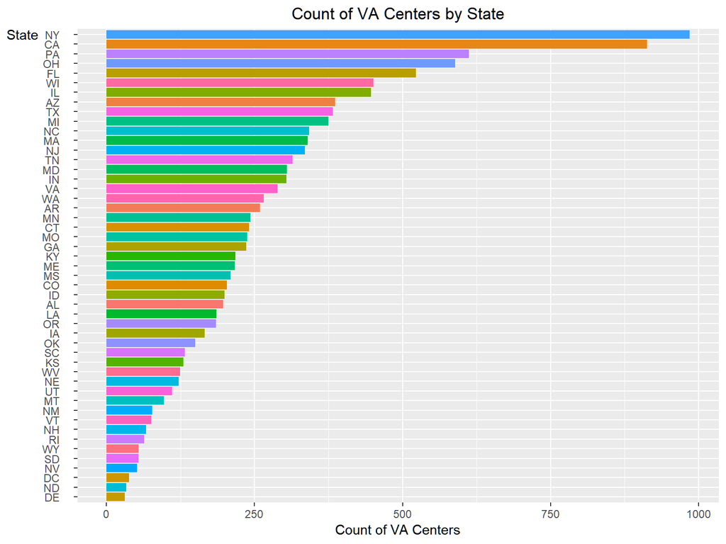

2019-06-17